# Classification Algorithms to detect Human Activity

Salman Virani

5-08-2022

# 1 Background

Using devices such as Jawbone Up, Nike FuelBand, and Fitbit it is now possible to collect a large amount of data about personal activity relatively inexpensively. These type of devices are part of the quantified self movement – a group of enthusiasts who take measurements about themselves regularly to improve their health, to find patterns in their behavior, or because they are tech geeks. One thing that people regularly do is quantify how much of a particular activity they do, but they rarely quantify how well they do it. This project will use data from accelerometers on the belt, forearm, arm, and dumbell of 6 participants. They were asked to perform barbell lifts correctly and incorrectly in 5 different ways. More information is available from the website here: http://groupware.les.inf.puc-rio.br/har

The study will predict the manner in which people do the exercise. This is the **classes** variable in the train set.

The five different ‘classe’ factors in this dataset are: * Exactly according to the specification (Class A) * Throwing the elbows to the front (Class B) * Lifting the dumbbell only halfway (Class C) * Lowering the dumbbell only halfway (Class D) * Throwing the hips to the front (Class E)

Data comes from this [source](https://d396qusza40orc.cloudfront.net/predmachlearn/pml-training.csv)

## 1.1 Libraries

The study uses the following libraries from CRAN; **readr**, **rsample**, **dplyr**, **nnet**, **rpart** and **caret**.

```r
suppressPackageStartupMessages(library(readr))
suppressPackageStartupMessages(library(dplyr))
suppressPackageStartupMessages(library(nnet))
suppressPackageStartupMessages(library(caret))
suppressPackageStartupMessages(library(rsample))
suppressPackageStartupMessages(library(rpart))
suppressPackageStartupMessages(library(randomForest))
```

## 1.2 Data

If the data is not available, then it will be downloaded and read into R. Data will be divided into **train** and **test**. A basic snap of the data is as below. It has 160 variables, among which the target varaible is **classe**

```r
file_path1 <- "./data/training.csv"

if(!file.exists(file_path1)){
  dir.create("./data")
  url <- "https://d396qusza40orc.cloudfront.net/predmachlearn/pml-training.csv"
  download.file(url, file_path1)
}


data <- read_csv("./data/training.csv")

head(data)
```

```
# A tibble: 6 x 160
   ...1 user_name raw_timestamp_part~ raw_timestamp_p~ cvtd_timestamp new_window
  <dbl> <chr>                   <dbl>            <dbl> <chr>          <chr>
1     1 carlitos           1323084231           788290 05/12/2011 11~ no
2     2 carlitos           1323084231           808298 05/12/2011 11~ no
3     3 carlitos           1323084231           820366 05/12/2011 11~ no
4     4 carlitos           1323084232           120339 05/12/2011 11~ no
5     5 carlitos           1323084232           196328 05/12/2011 11~ no
6     6 carlitos           1323084232           304277 05/12/2011 11~ no
# ... with 154 more variables: num_window <dbl>, roll_belt <dbl>,
#   pitch_belt <dbl>, yaw_belt <dbl>, total_accel_belt <dbl>,
#   kurtosis_roll_belt <chr>, kurtosis_picth_belt <chr>,
#   kurtosis_yaw_belt <chr>, skewness_roll_belt <dbl>,
#   skewness_roll_belt.1 <chr>, skewness_yaw_belt <chr>, max_roll_belt <dbl>,
#   max_picth_belt <dbl>, max_yaw_belt <chr>, min_roll_belt <dbl>,
#   min_pitch_belt <dbl>, min_yaw_belt <chr>, amplitude_roll_belt <dbl>, ...
```

# 2 Data Wrangling

Some unnecessary columns needs to be removed before moving to modeling stage. Firstly, the columns that have more than 19000 NAs are removed. Secondly, **classe** column has been converted to factors. Thirdly, the initial data is split into train and test. Lastly, some unnecessary columns like id, timestamp etc have been removed.

```r
remove_col <- colSums(is.na(data)) > 19000
data <- data[,!remove_col]
data <- data %>%
  select(-1:-7)

data$classe <- as.factor(data$classe)

initial_split <- initial_split(data, prop = 0.8)
train <- training(initial_split)
test <- testing(initial_split)
rm(initial_split)
```

## 2.1 Descriptive Statistics

A statistical summary of different variables of test data is provided below.

```r
summary(test)
```

```
   roll_belt        pitch_belt          yaw_belt       total_accel_belt
 Min.   :-28.60   Min.   :-53.9000   Min.   :-179.00   Min.   : 1.00
 1st Qu.:  1.12   1st Qu.:  1.9500   1st Qu.: -88.30   1st Qu.: 3.00
 Median :115.00   Median :  5.4000   Median :  -9.10   Median :17.00
 Mean   : 65.43   Mean   :  0.6522   Mean   : -10.29   Mean   :11.46
 3rd Qu.:123.00   3rd Qu.: 15.7000   3rd Qu.:   8.91   3rd Qu.:18.00
 Max.   :161.00   Max.   : 60.1000   Max.   : 179.00   Max.   :28.00
  gyros_belt_x        gyros_belt_y      gyros_belt_z      accel_belt_x
 Min.   :-0.960000   Min.   :-0.6400   Min.   :-1.1500   Min.   :-83.000
 1st Qu.:-0.050000   1st Qu.: 0.0000   1st Qu.:-0.2000   1st Qu.:-21.000
 Median : 0.030000   Median : 0.0200   Median :-0.1100   Median :-15.000
 Mean   :-0.004224   Mean   : 0.0416   Mean   :-0.1289   Mean   : -5.977
 3rd Qu.: 0.110000   3rd Qu.: 0.1100   3rd Qu.:-0.0200   3rd Qu.: -5.000
 Max.   : 1.880000   Max.   : 0.6400   Max.   : 1.4100   Max.   : 81.000
  accel_belt_y    accel_belt_z    magnet_belt_x    magnet_belt_y
 Min.   :-38.0   Min.   :-266.0   Min.   :-46.00   Min.   :354.0
 1st Qu.:  3.0   1st Qu.:-162.0   1st Qu.:  9.00   1st Qu.:582.0
 Median : 39.0   Median :-154.0   Median : 34.00   Median :601.0
 Mean   : 30.8   Mean   : -74.4   Mean   : 55.29   Mean   :593.5
 3rd Qu.: 61.0   3rd Qu.:  27.0   3rd Qu.: 58.00   3rd Qu.:610.0
 Max.   :149.0   Max.   : 103.0   Max.   :474.00   Max.   :667.0
 magnet_belt_z       roll_arm        pitch_arm          yaw_arm
 Min.   :-621.0   Min.   :-177.0   Min.   :-87.900   Min.   :-179.000
 1st Qu.:-372.0   1st Qu.: -34.6   1st Qu.:-26.300   1st Qu.: -44.200
 Median :-319.0   Median :   0.0   Median :  0.000   Median :   0.000
 Mean   :-344.7   Mean   :  17.6   Mean   : -4.321   Mean   :  -2.144
 3rd Qu.:-306.0   3rd Qu.:  77.0   3rd Qu.: 12.100   3rd Qu.:  44.400
 Max.   : 286.0   Max.   : 178.0   Max.   : 86.400   Max.   : 180.000
 total_accel_arm  gyros_arm_x        gyros_arm_y       gyros_arm_z
 Min.   : 1.00   Min.   :-6.34000   Min.   :-3.2600   Min.   :-2.3300
 1st Qu.:17.00   1st Qu.:-1.27000   1st Qu.:-0.8000   1st Qu.:-0.0700
 Median :26.00   Median : 0.10000   Median :-0.2700   Median : 0.2600
 Mean   :25.44   Mean   : 0.06406   Mean   :-0.2614   Mean   : 0.2784
 3rd Qu.:32.00   3rd Qu.: 1.59000   3rd Qu.: 0.1400   3rd Qu.: 0.7200
 Max.   :66.00   Max.   : 4.87000   Max.   : 2.8100   Max.   : 2.6900
  accel_arm_x       accel_arm_y       accel_arm_z       magnet_arm_x
 Min.   :-337.00   Min.   :-248.00   Min.   :-636.00   Min.   :-584.0
 1st Qu.:-242.00   1st Qu.: -55.00   1st Qu.:-141.00   1st Qu.:-302.0
 Median : -46.00   Median :  13.00   Median : -46.00   Median : 263.0
 Mean   : -61.47   Mean   :  31.13   Mean   : -69.45   Mean   : 186.6
```

[output cut: 36 more lines]

```
 Max.   : 89.80   Max.   : 180.00   Max.   :62.00       Max.   : 3.9700
 gyros_forearm_y    gyros_forearm_z   accel_forearm_x   accel_forearm_y
 Min.   :-6.54000   Min.   :-8.0900   Min.   :-473.00   Min.   :-456.0
 1st Qu.:-1.41000   1st Qu.:-0.1800   1st Qu.:-177.00   1st Qu.:  52.0
 Median : 0.03000   Median : 0.0800   Median : -57.00   Median : 202.0
 Mean   : 0.05308   Mean   : 0.1284   Mean   : -64.31   Mean   : 163.1
 3rd Qu.: 1.57000   3rd Qu.: 0.4900   3rd Qu.:  69.00   3rd Qu.: 315.0
 Max.   : 6.13000   Max.   : 4.1000   Max.   : 389.00   Max.   : 591.0
 accel_forearm_z   magnet_forearm_x  magnet_forearm_y magnet_forearm_z classe
 Min.   :-391.00   Min.   :-1270.0   Min.   :-870.0   Min.   :-964.0   A:1110
 1st Qu.:-182.00   1st Qu.: -609.0   1st Qu.:  17.0   1st Qu.: 194.0   B: 753
 Median : -39.00   Median : -371.0   Median : 600.0   Median : 510.0   C: 697
 Mean   : -56.38   Mean   : -314.8   Mean   : 388.5   Mean   : 393.4   D: 673
 3rd Qu.:  24.00   3rd Qu.:  -80.0   3rd Qu.: 741.0   3rd Qu.: 651.0   E: 692
 Max.   : 287.00   Max.   :  661.0   Max.   :1480.0   Max.   :1050.0
```

# 3 Multinomial Logistic Regression Model

```r
model_multilog <- multinom(classe~., data = train)
train <- train %>%
  mutate(pred_multilog = predict(model_multilog, newdata = train))

test <- test %>%
  mutate(pred_multilog = predict(model_multilog, newdata = test))
```

## 3.1 Accuracy Measures

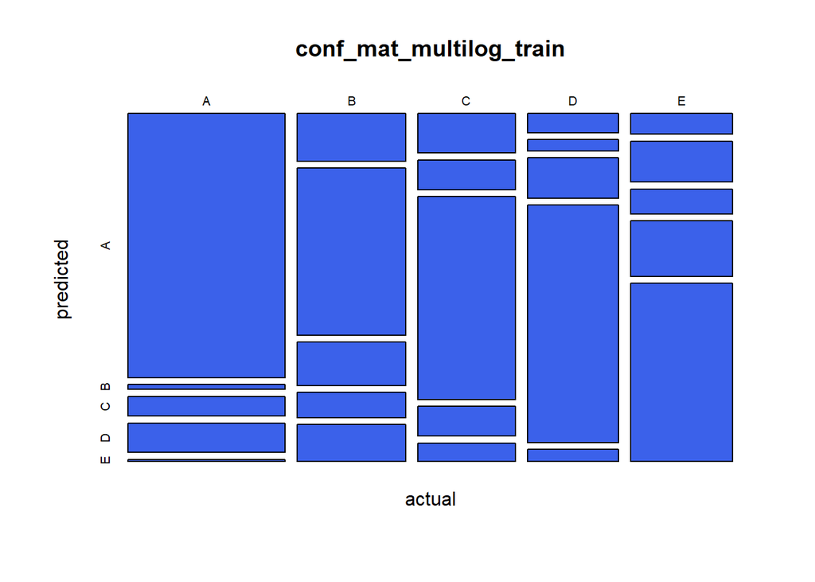

```r
conf_mat_multilog_train <- table(actual = train$classe, predicted = train$pred_multilog)

conf_mat_multilog_test <- table(actual = test$classe, predicted = test$pred_multilog)

plot(conf_mat_multilog_train, color = "#3B61EA")
```

```r
confusionMatrix(conf_mat_multilog_train)
```

```
Confusion Matrix and Statistics

      predicted
actual    A    B    C    D    E
     A 3658   68  271  408   30
     B  456 1598  415  242  354
     C  339  256 1747  256  158
     D  154   88  325 1902   98
     E  186  366  225  498 1599

Overall Statistics

               Accuracy : 0.6692
                 95% CI : (0.6617, 0.6765)
    No Information Rate : 0.3053
    P-Value [Acc > NIR] : < 2.2e-16

                  Kappa : 0.5814

 Mcnemar's Test P-Value : < 2.2e-16

Statistics by Class:

                     Class: A Class: B Class: C Class: D Class: E
Sensitivity            0.7632   0.6726   0.5857   0.5753   0.7142
Specificity            0.9287   0.8899   0.9206   0.9463   0.9053
Pos Pred Value         0.8248   0.5214   0.6339   0.7409   0.5564
Neg Pred Value         0.8992   0.9384   0.9045   0.8931   0.9501
Prevalence             0.3053   0.1514   0.1900   0.2106   0.1426
Detection Rate         0.2330   0.1018   0.1113   0.1212   0.1019
Detection Prevalence   0.2825   0.1953   0.1756   0.1635   0.1831
Balanced Accuracy      0.8460   0.7812   0.7531   0.7608   0.8097
```

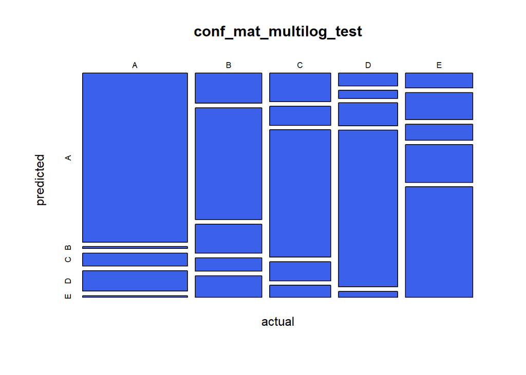

```r
plot(conf_mat_multilog_test, color = "#3B61EA")
```

```r
confusionMatrix(conf_mat_multilog_test)
```

```
Confusion Matrix and Statistics

      predicted
actual   A   B   C   D   E
     A 938  11  72 114  10
     B 107 397 103  48  77
     C  92  62 411  62  39
     D  40  25  72 493  19
     E  53  96  57 134 393

Overall Statistics

               Accuracy : 0.6706
                 95% CI : (0.6556, 0.6853)
    No Information Rate : 0.3134
    P-Value [Acc > NIR] : < 2.2e-16

                  Kappa : 0.582

 Mcnemar's Test P-Value : < 2.2e-16

Statistics by Class:

                     Class: A Class: B Class: C Class: D Class: E
Sensitivity            0.7626   0.6717   0.5748   0.5793   0.7305
Specificity            0.9232   0.8995   0.9206   0.9493   0.8996
Pos Pred Value         0.8192   0.5423   0.6171   0.7596   0.5362
Neg Pred Value         0.8950   0.9392   0.9067   0.8907   0.9546
Prevalence             0.3134   0.1506   0.1822   0.2168   0.1371
Detection Rate         0.2390   0.1011   0.1047   0.1256   0.1001
Detection Prevalence   0.2917   0.1865   0.1697   0.1654   0.1868
Balanced Accuracy      0.8429   0.7856   0.7477   0.7643   0.8150
```

# 4 KNN

```r
model_knn <- train(classe~., data = train, method = "knn")
model_knn
```

```
k-Nearest Neighbors

15697 samples
   53 predictor
    5 classes: 'A', 'B', 'C', 'D', 'E'

No pre-processing
Resampling: Bootstrapped (25 reps)
Summary of sample sizes: 15697, 15697, 15697, 15697, 15697, 15697, ...
Resampling results across tuning parameters:

  k  Accuracy   Kappa
  5  0.8818981  0.8506452
  7  0.8656429  0.8300826
  9  0.8525268  0.8134877

Accuracy was used to select the optimal model using the largest value.
The final value used for the model was k = 5.
```

## 4.1 Accuracy measures

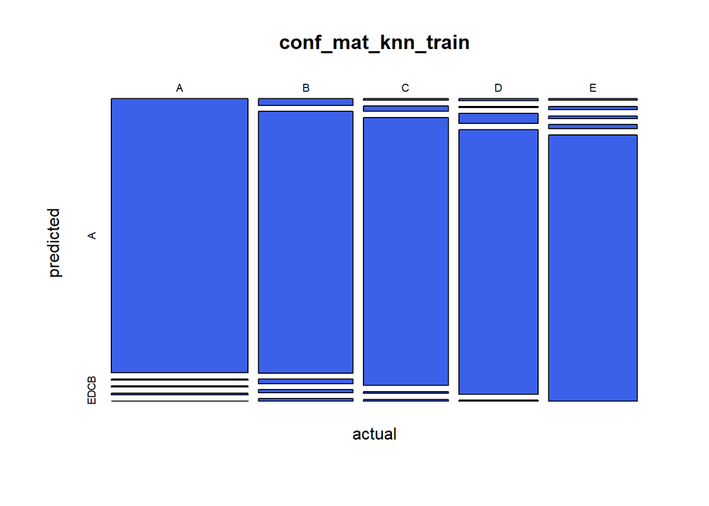

```r
train$pred_knn <- predict(model_knn, newdata = train)

conf_mat_knn_train <- table(actual = train$classe,
                               predicted = train$pred_knn)

plot(conf_mat_knn_train, color = "#3B61EA")
```

```r
confusionMatrix(conf_mat_knn_train)
```

```
Confusion Matrix and Statistics

      predicted
actual    A    B    C    D    E
     A 4368   18   15   30    4
     B   72 2882   51   31   29
     C   13   51 2655   19   18
     D   17    6   94 2441    9
     E   17   35   28   42 2752

Overall Statistics

               Accuracy : 0.9618
                 95% CI : (0.9587, 0.9648)
    No Information Rate : 0.2859
    P-Value [Acc > NIR] : < 2.2e-16

                  Kappa : 0.9517

 Mcnemar's Test P-Value : < 2.2e-16

Statistics by Class:

                     Class: A Class: B Class: C Class: D Class: E
Sensitivity            0.9735   0.9632   0.9339   0.9524   0.9787
Specificity            0.9940   0.9856   0.9921   0.9904   0.9905
Pos Pred Value         0.9849   0.9403   0.9634   0.9509   0.9576
Neg Pred Value         0.9894   0.9913   0.9855   0.9907   0.9953
Prevalence             0.2859   0.1906   0.1811   0.1633   0.1791
Detection Rate         0.2783   0.1836   0.1691   0.1555   0.1753
Detection Prevalence   0.2825   0.1953   0.1756   0.1635   0.1831
Balanced Accuracy      0.9838   0.9744   0.9630   0.9714   0.9846
```

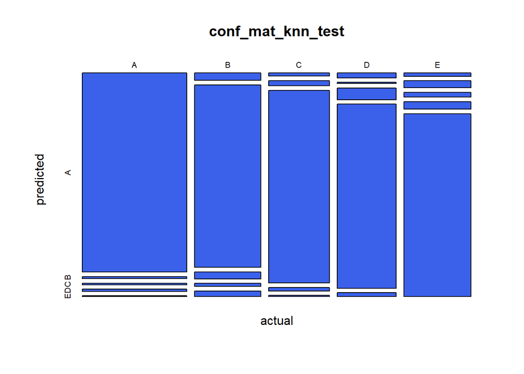

```r
test$pred_knn <- predict(model_knn, newdata = test)

conf_mat_knn_test <- table(actual = test$classe,
                                 predicted = test$pred_knn)

plot(conf_mat_knn_test, color = "#3B61EA")
```

```r
confusionMatrix(conf_mat_knn_test)
```

```
Confusion Matrix and Statistics

      predicted
actual    A    B    C    D    E
     A 1108   12    9   12    4
     B   26  650   25   11   20
     C   10   17  624   11    4
     D   15    4   37  581   12
     E   12   25   17   27  652

Overall Statistics

               Accuracy : 0.921
                 95% CI : (0.9121, 0.9293)
    No Information Rate : 0.2983
    P-Value [Acc > NIR] : < 2.2e-16

                  Kappa : 0.8998

 Mcnemar's Test P-Value : 5.422e-06

Statistics by Class:

                     Class: A Class: B Class: C Class: D Class: E
Sensitivity            0.9462   0.9181   0.8764   0.9050   0.9422
Specificity            0.9866   0.9745   0.9869   0.9793   0.9749
Pos Pred Value         0.9677   0.8880   0.9369   0.8952   0.8895
Neg Pred Value         0.9773   0.9818   0.9730   0.9814   0.9875
Prevalence             0.2983   0.1804   0.1814   0.1636   0.1763
Detection Rate         0.2823   0.1656   0.1590   0.1480   0.1661
Detection Prevalence   0.2917   0.1865   0.1697   0.1654   0.1868
Balanced Accuracy      0.9664   0.9463   0.9317   0.9421   0.9586
```

# 5 Decision Trees

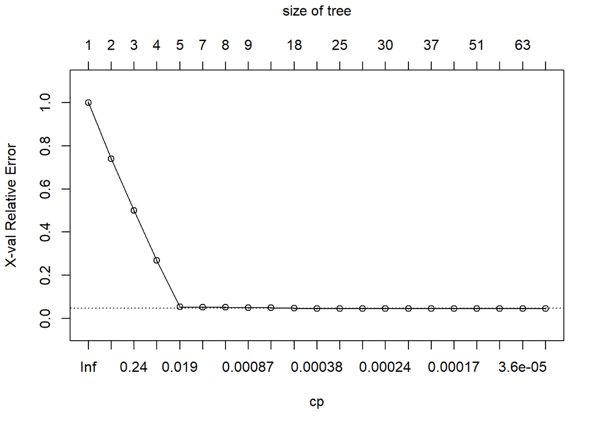

```r
model_dc <- rpart(classe~., data = train, method = "class",
                control = rpart.control(cp = 0))

plotcp(model_dc)
```

```r
printcp(model_dc)
```

```
Classification tree:
rpart(formula = classe ~ ., data = train, method = "class", control = rpart.control(cp = 0))

Variables actually used in tree construction:
 [1] accel_arm_y       accel_arm_z       accel_belt_x      accel_belt_y
 [5] accel_belt_z      accel_dumbbell_y  accel_dumbbell_z  gyros_arm_x
 [9] gyros_arm_y       gyros_belt_y      gyros_belt_z      gyros_dumbbell_x
[13] gyros_dumbbell_y  gyros_forearm_x   gyros_forearm_y   gyros_forearm_z
[17] magnet_arm_x      magnet_arm_y      magnet_belt_x     magnet_dumbbell_y
[21] magnet_dumbbell_z pitch_arm         pitch_belt        pitch_dumbbell
[25] pitch_forearm     pred_knn          pred_multilog     roll_arm
[29] roll_belt         total_accel_arm   yaw_arm           yaw_belt
[33] yaw_dumbbell

Root node error: 11262/15697 = 0.71746
```

[output cut: 25 more lines]

## 5.1 Pruning

Pruning a decision tree based on complexity parameter allows to extract better results from a decision tree model.

```r
model_dc_pruned <- prune(model_dc, cp = 2.2799e-04)
rm(model_dc)
```

## 5.2 Accuracy Measures

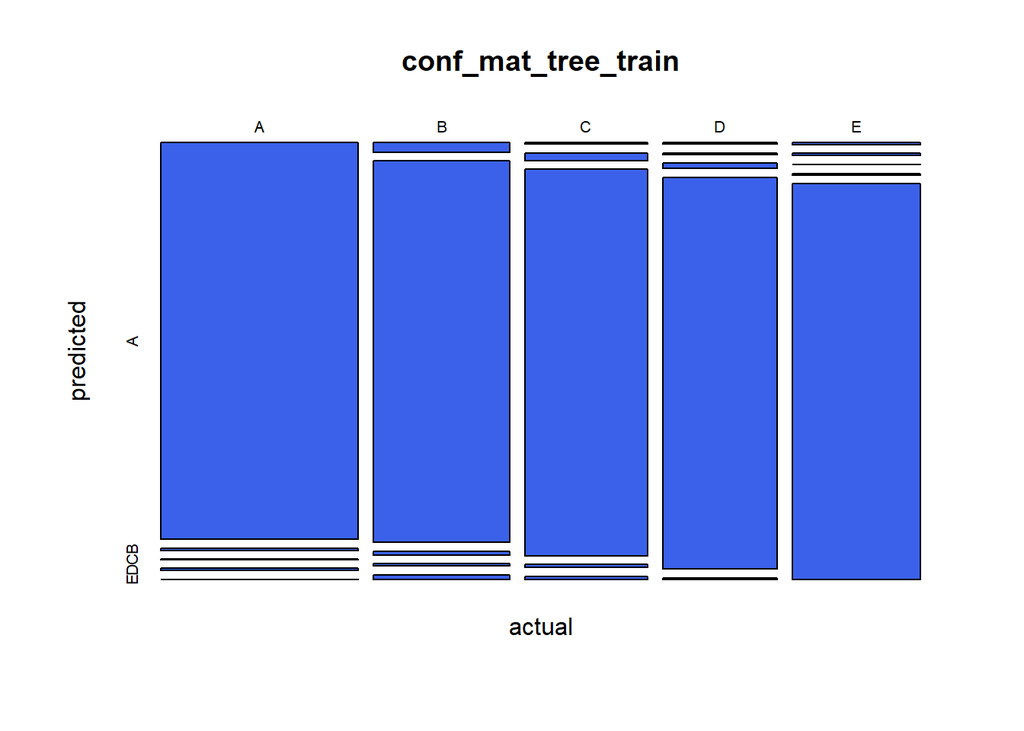

```r
train$pred_dc <- predict(model_dc_pruned, newdata = train, type = "class")

conf_mat_tree_train <- table(actual = train$classe,
                                predicted = train$pred_dc)

plot(conf_mat_tree_train, color = "#3B61EA")
```

```r
confusionMatrix(conf_mat_tree_train)
```

```
Confusion Matrix and Statistics

      predicted
actual    A    B    C    D    E
     A 4376   23    8   23    5
     B   73 2909   27   19   37
     C    9   54 2649   21   23
     D   10   10   33 2501   13
     E   12   19    1   12 2830

Overall Statistics

               Accuracy : 0.9725
                 95% CI : (0.9698, 0.975)
    No Information Rate : 0.2854
    P-Value [Acc > NIR] : < 2.2e-16

                  Kappa : 0.9652

 Mcnemar's Test P-Value : 5.804e-12

Statistics by Class:

                     Class: A Class: B Class: C Class: D Class: E
Sensitivity            0.9768   0.9648   0.9746   0.9709   0.9732
Specificity            0.9947   0.9877   0.9918   0.9950   0.9966
Pos Pred Value         0.9867   0.9491   0.9612   0.9743   0.9847
Neg Pred Value         0.9908   0.9916   0.9947   0.9943   0.9939
Prevalence             0.2854   0.1921   0.1732   0.1641   0.1853
Detection Rate         0.2788   0.1853   0.1688   0.1593   0.1803
Detection Prevalence   0.2825   0.1953   0.1756   0.1635   0.1831
Balanced Accuracy      0.9858   0.9763   0.9832   0.9829   0.9849
```

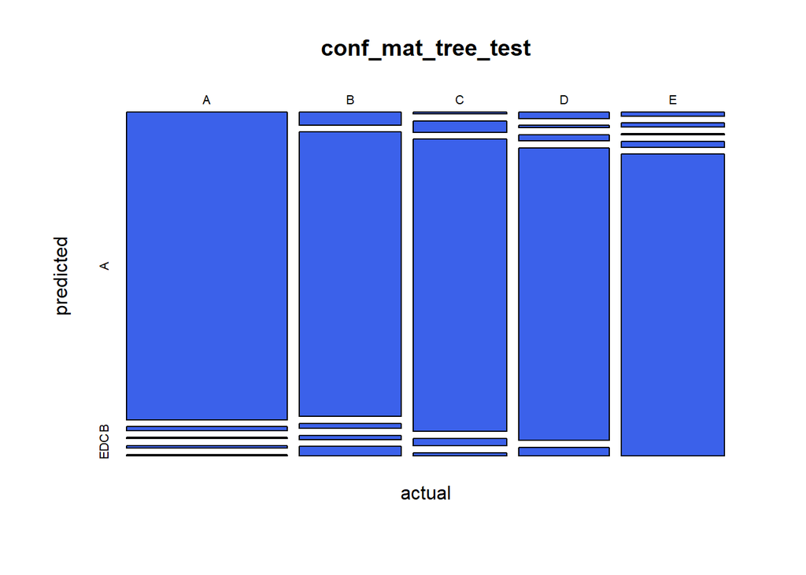

```r
test$pred_dc <- predict(model_dc_pruned, newdata = test, type = "class")

conf_mat_tree_test <- table(actual = test$classe,
                           predicted = test$pred_dc)

plot(conf_mat_tree_test, color = "#3B61EA")
```

```r
confusionMatrix(conf_mat_tree_test)
```

```
Confusion Matrix and Statistics

      predicted
actual    A    B    C    D    E
     A 1113   15    4    9    4
     B   30  658   12   10   22
     C    4   24  615   16    7
     D   13    5   13  600   18
     E    9    9    2   13  700

Overall Statistics

               Accuracy : 0.9391
                 95% CI : (0.9312, 0.9464)
    No Information Rate : 0.2978
    P-Value [Acc > NIR] : < 2e-16

                  Kappa : 0.9228

 Mcnemar's Test P-Value : 0.01206

Statistics by Class:

                     Class: A Class: B Class: C Class: D Class: E
Sensitivity            0.9521   0.9255   0.9520   0.9259   0.9321
Specificity            0.9884   0.9770   0.9844   0.9850   0.9896
Pos Pred Value         0.9721   0.8989   0.9234   0.9245   0.9550
Neg Pred Value         0.9799   0.9834   0.9905   0.9853   0.9840
Prevalence             0.2978   0.1811   0.1646   0.1651   0.1913
Detection Rate         0.2836   0.1676   0.1567   0.1529   0.1783
Detection Prevalence   0.2917   0.1865   0.1697   0.1654   0.1868
Balanced Accuracy      0.9702   0.9512   0.9682   0.9555   0.9608
```

# 6 Ensemble Method: Random Forest

```r
model_rf <- randomForest(formula = classe~., data = train, ntree = 500)
```

## 6.1 Accuracy Measures

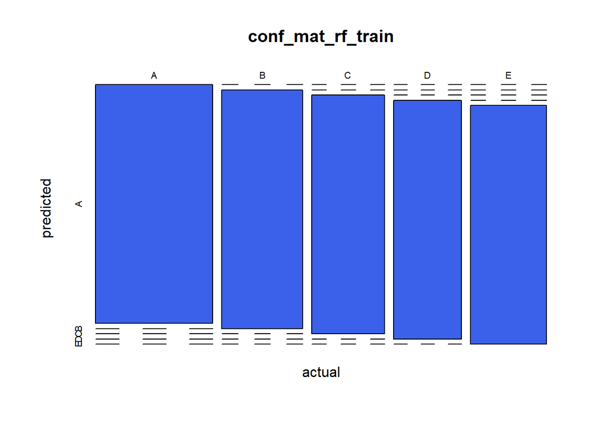

```r
train$pred_rf <- predict(model_rf, newdata = train)
conf_mat_rf_train <- table(actual = train$classe, predicted = train$pred_rf)

plot(conf_mat_rf_train, color = "#3B61EA")
```

```r
confusionMatrix(conf_mat_rf_train)
```

```
## Confusion Matrix and Statistics
##
##       predicted
## actual    A    B    C    D    E
##      A 4435    0    0    0    0
##      B    0 3065    0    0    0
##      C    0    0 2756    0    0
##      D    0    0    0 2567    0
##      E    0    0    0    0 2874
##
## Overall Statistics
##
##                Accuracy : 1
##                  95% CI : (0.9998, 1)
##     No Information Rate : 0.2825
##     P-Value [Acc > NIR] : < 2.2e-16
##
##                   Kappa : 1
##
##  Mcnemar's Test P-Value : NA
##
## Statistics by Class:
##
##                      Class: A Class: B Class: C Class: D Class: E
## Sensitivity            1.0000   1.0000   1.0000   1.0000   1.0000
## Specificity            1.0000   1.0000   1.0000   1.0000   1.0000
## Pos Pred Value         1.0000   1.0000   1.0000   1.0000   1.0000
## Neg Pred Value         1.0000   1.0000   1.0000   1.0000   1.0000
## Prevalence             0.2825   0.1953   0.1756   0.1635   0.1831
## Detection Rate         0.2825   0.1953   0.1756   0.1635   0.1831
## Detection Prevalence   0.2825   0.1953   0.1756   0.1635   0.1831
## Balanced Accuracy      1.0000   1.0000   1.0000   1.0000   1.0000
```

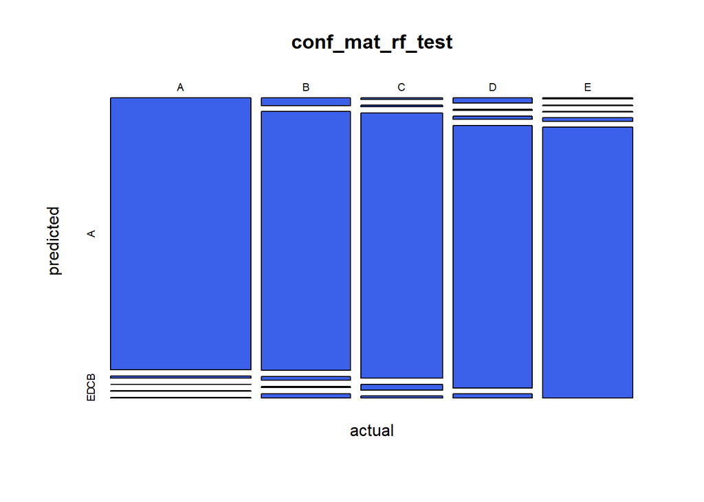

```r
test$pred_rf <- predict(model_rf, newdata = test)
conf_mat_rf_test <- table(actual = test$classe, predicted = test$pred_rf)

plot(conf_mat_rf_test, color = "#3B61EA")
```

```r
confusionMatrix(conf_mat_rf_test)
```

```
## Confusion Matrix and Statistics
##
##       predicted
## actual    A    B    C    D    E
##      A 1128    9    1    4    3
##      B   20  686   11    3   12
##      C    3    4  640   14    5
##      D   12    3    7  617   10
##      E    3    1    1    9  719
##
## Overall Statistics
##
##                Accuracy : 0.9656
##                  95% CI : (0.9594, 0.9711)
##     No Information Rate : 0.2971
##     P-Value [Acc > NIR] : < 2.2e-16
##
##                   Kappa : 0.9564
##
##  Mcnemar's Test P-Value : 0.002802
##
## Statistics by Class:
##
##                      Class: A Class: B Class: C Class: D Class: E
## Sensitivity            0.9674   0.9758   0.9697   0.9536   0.9599
## Specificity            0.9938   0.9857   0.9920   0.9902   0.9956
## Pos Pred Value         0.9852   0.9372   0.9610   0.9507   0.9809
## Neg Pred Value         0.9863   0.9947   0.9939   0.9908   0.9906
## Prevalence             0.2971   0.1791   0.1682   0.1648   0.1908
## Detection Rate         0.2874   0.1748   0.1631   0.1572   0.1832
## Detection Prevalence   0.2917   0.1865   0.1697   0.1654   0.1868
## Balanced Accuracy      0.9806   0.9808   0.9809   0.9719   0.9778
```

# 7 Conclusion

Random Forests provides the best prediction rates. However, one important thing to note here is that the training data prediction rate of random forest algorithm is 1. This suggests some over fitting as the testing data prediction rate decreases to 0.9656. These are some advanced topics not currently in the scope of this project, but will be discussed in the upcoming projects.

I hope you have enjoyed and learned from this project. You can support me my keeping yourself updated with future projects. For that, kindly follow my [GitHub](https://github.com/virani1997) and [Twitter](https://twitter.com/SalmanVirani6) profiles.